# Question

## Matrix of original points (preimage)

A list of 2D-cartesian points is stored as the preimage matrix. Each row represents one point.

$$P = \begin{bmatrix}
0 & 0\\
6 & 4\\
-6 & -1\\
-1 & 3\\
6 & 6\\
-6 & 5\\
-3 & -3\\
5 & 7\\
7 & 5
\end{bmatrix}$$

Those points can be expressed in [SageMath](https://sagecell.sagemath.org/).

```
P = matrix([[0,0],[6,4],[-6,-1],[-1,3],[6,6],[-6,5],[-3,-3],[5,7],[7,5]])
```

If you wanted to visualize those points, you could use the [point function](https://doc.sagemath.org/html/en/reference/plotting/sage/plot/point.html).

```
point(P,xmin=-10,xmax=10,ymin=-10,ymax=10,size=50,aspect_ratio=1)
```

## Rotation matrix

We want to rotate the points by $\theta=1.75$ radians counterclockwise. We will do this by matrix multiplication with the 2D rotation matrix. (*We are using a right-operand rotation matrix. The standard approach is to use a left-operand rotation matrix, but I think - for complicated reasons - that we’ll be better off using right-operand transformations.*)

$$R = \begin{bmatrix}\cos(\theta) &
\sin(\theta) \\ -\sin(\theta) & \cos(\theta)
\end{bmatrix}$$

## Image

We can apply the rotation to the points by using matrix multiplication. Remember, matrix multiplication is not commutative. Let $F$ represent a matrix holding the **f**inal positions of the image (after the transformation).

$$F = P\cdot R$$

After you calculate $F$, you can plot the points in $F$ with the following code (in SageMath):

```
point(F,xmin=-10,xmax=10,ymin=-10,ymax=10,size=50)
```

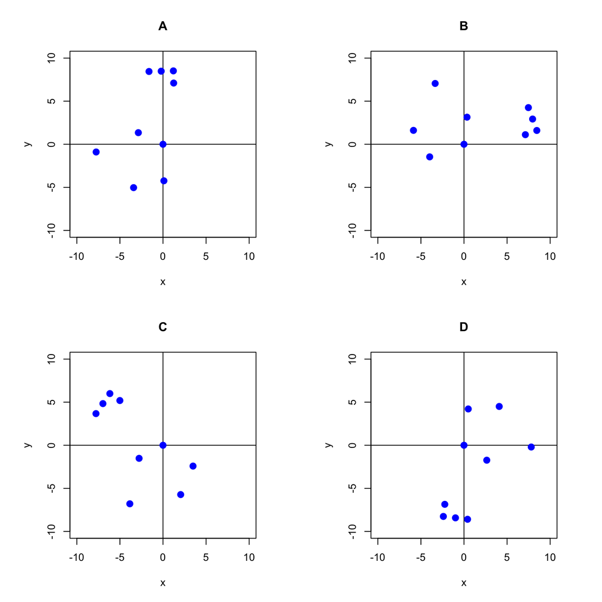

## Answerlist

- A
- B
- C
- D

# Solution

```
P = matrix([[0,0],[6,4],[-6,-1],[-1,3],[6,6],[-6,5],[-3,-3],[5,7],[7,5]])
theta = 1.75
R = matrix([[cos(theta),sin(theta)],
            [-sin(theta),cos(theta)]])
F = P*R
point(F,xmin=-10,xmax=10,ymin=-10,ymax=10,size=50,aspect_ratio=1)
```

I think you might appreciate seeing points of matrix $P$ alongside points of matrix $F$. You can get that by running the code shown below:

```
P = matrix([[0,0],[6,4],[-6,-1],[-1,3],[6,6],[-6,5],[-3,-3],[5,7],[7,5]])
theta = 1.75
R = matrix([[cos(theta),sin(theta)],
            [-sin(theta),cos(theta)]])
F = P*R
G = Graphics()
G += point(P,hue=0,xmin=-10,xmax=10,ymin=-10,ymax=10,size=50,aspect_ratio=1)
G += point(F,hue=0.7,size=50)
show(G)
```

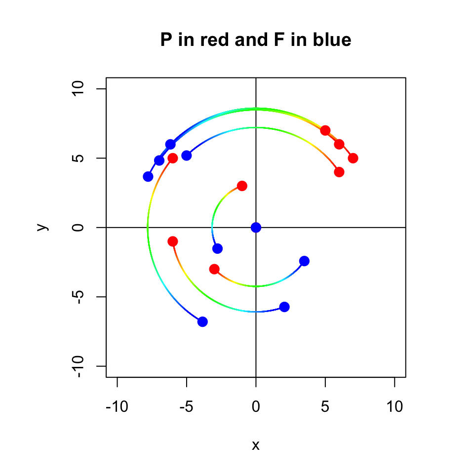

# Meta-information

extype: schoice exsolution: 0010 exname: rotate_2D